# Coursera Practical Machine Learning Assignment

## Analysis

Now we fit a tree to these data, and summarize and plot it. First, we use the ‘tree’ package. It is much faster than ‘caret’ package.

```r
library(tree)
set.seed(12345)
tree.training=tree(classe~.,data=training)
summary(tree.training)
```

```
##
## Classification tree:
## tree(formula = classe ~ ., data = training)
## Variables actually used in tree construction:
##  [1] "pitch_forearm"     "magnet_belt_y"     "accel_forearm_z"
##  [4] "magnet_dumbbell_y" "roll_forearm"      "magnet_dumbbell_z"
##  [7] "yaw_belt"          "accel_dumbbell_y"  "pitch_belt"
## [10] "accel_forearm_x"   "accel_dumbbell_z"  "magnet_arm_x"
## [13] "gyros_belt_z"
## Number of terminal nodes:  24
## Residual mean deviance:  1.491 = 20440 / 13710
## Misclassification error rate: 0.2887 = 3966 / 13737
```

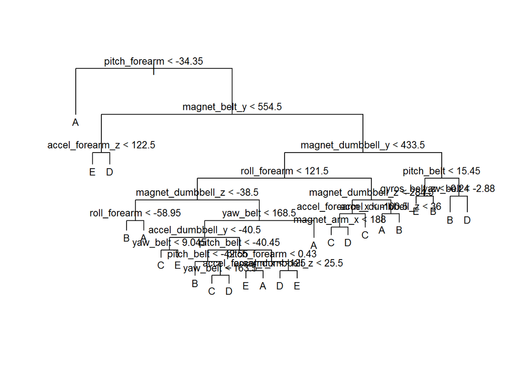

```r
plot(tree.training)
text(tree.training,pretty=0, cex =.8)
```

This is a bushy tree, and we are going to prune it.

For a detailed summary of the tree, print it:

```r
#tree.training
library(caret)
modFit <- train(classe ~ .,method="rpart",data=training)
print(modFit$finalModel)
```

```
## n= 13737
##
## node), split, n, loss, yval, (yprob)
##       * denotes terminal node
##
##  1) root 13737 9831 A (0.28 0.19 0.17 0.16 0.18)
##    2) pitch_forearm< -34.15 1114    4 A (1 0.0036 0 0 0) *
##    3) pitch_forearm>=-34.15 12623 9827 A (0.22 0.21 0.19 0.18 0.2)
##      6) magnet_belt_y>=554.5 11612 8817 A (0.24 0.23 0.21 0.18 0.15)
##       12) magnet_dumbbell_y< 426.5 9557 6843 A (0.28 0.18 0.24 0.17 0.13)
##         24) roll_forearm< 121.5 5940 3523 A (0.41 0.18 0.19 0.14 0.092) *
##         25) roll_forearm>=121.5 3617 2408 C (0.082 0.18 0.33 0.22 0.18) *
##       13) magnet_dumbbell_y>=426.5 2055 1108 B (0.039 0.46 0.042 0.21 0.24)
##         26) total_accel_dumbbell>=5.5 1437  577 B (0.056 0.6 0.058 0.026 0.26) *
##         27) total_accel_dumbbell< 5.5 618  215 D (0 0.14 0.0049 0.65 0.2) *
##      7) magnet_belt_y< 554.5 1011  191 E (0.00099 0.00099 0 0.19 0.81) *
```

### Prettier plots

```r
library(rattle)
```

[figure not shown]

```r
fancyRpartPlot(modFit$finalModel)
```

## Cross Validation

We are going to check the performance of the tree on the testing data by cross validation.

```r
tree.pred=predict(tree.training,testing,type="class")
predMatrix = with(testing,table(tree.pred,classe))
sum(diag(predMatrix))/sum(as.vector(predMatrix)) # error rate
```

```
## [1] 0.7005947
```

The 0.70 is not very accurate.

```r
tree.pred=predict(modFit,testing)
predMatrix = with(testing,table(tree.pred,classe))
sum(diag(predMatrix))/sum(as.vector(predMatrix)) # error rate
```

```
## [1] 0.4963466
```

The 0.50 from ‘caret’ package is much lower than the result from ‘tree’ package.

## Pruning tree

This tree was grown to full depth, and might be too variable. We now use Cross Validation to prune it.

```r
cv.training=cv.tree(tree.training,FUN=prune.misclass)
cv.training
```

```
## $size
##  [1] 24 23 22 21 19 18 17 16 15 10  7  5  1
##
## $dev
##  [1] 3976 4003 4097 4106 4580 4785 5144 5226 6654 6746 6801 7260 9831
##
## $k
##  [1]   -Inf  31.00  80.00  84.00 131.50 147.00 165.00 171.00 195.00 204.00
## [11] 207.00 250.50 646.75
##
## $method
## [1] "misclass"
##
## attr(,"class")
## [1] "prune"         "tree.sequence"
```

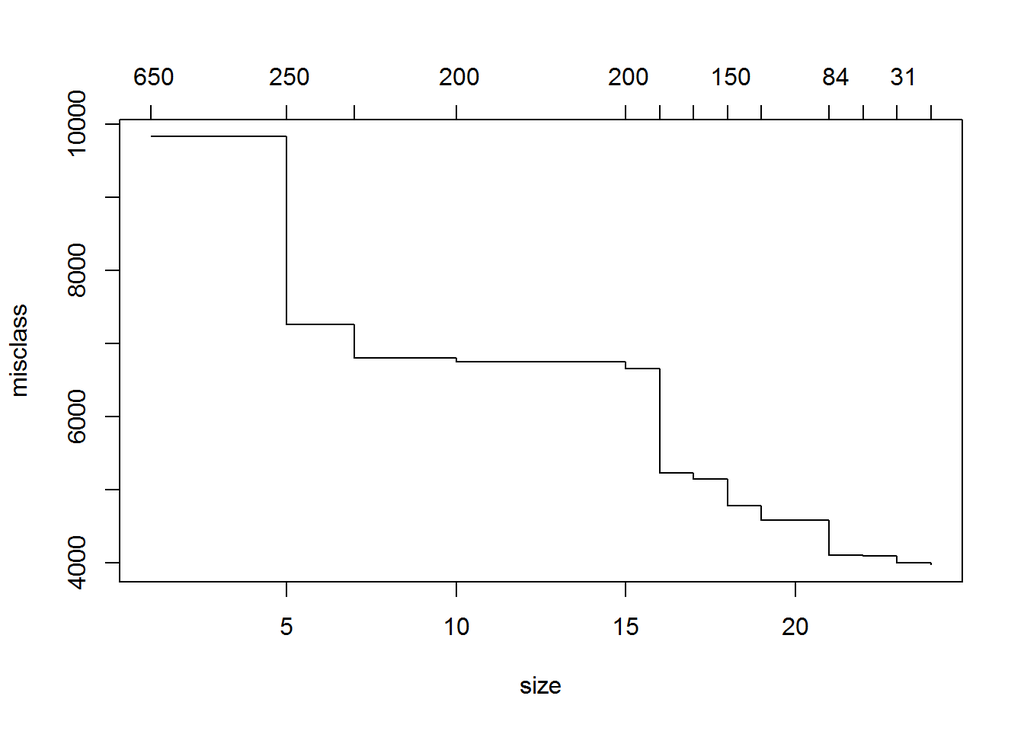

```r
plot(cv.training)
```

Suppose we prune it at size of nodes at 18.

```r
prune.training=prune.misclass(tree.training,best=18)
#plot(prune.training);text(prune.training,pretty=0,cex =.8 )
```

Now lets evaluate this pruned tree on the test data.

```r
tree.pred=predict(prune.training,testing,type="class")
predMatrix = with(testing,table(tree.pred,classe))
sum(diag(predMatrix))/sum(as.vector(predMatrix)) # error rate
```

```
## [1] 0.6591334
```

The single tree is not good enough, so we are going to use bootstrap to improve the accuracy. We are going to try random forests.

## Random Forests

These methods use trees as building blocks to build more complex models.

## Random Forests

Random forests build lots of bushy trees, and then average them to reduce the variance.

```r
require(randomForest)
set.seed(12345)
```

Lets fit a random forest and see how well it performs.

```r
rf.training=randomForest(classe~.,data=training,ntree=100, importance=TRUE)
rf.training
```

```
##
## Call:
##  randomForest(formula = classe ~ ., data = training, ntree = 100,      importance = TRUE)
##                Type of random forest: classification
##                      Number of trees: 100
## No. of variables tried at each split: 6
##
##         OOB estimate of  error rate: 0.58%
## Confusion matrix:
##      A    B    C    D    E class.error
## A 3902    3    0    0    1 0.001024066
## B   12 2637    9    0    0 0.007900677
## C    0   17 2375    4    0 0.008764608
## D    0    0   22 2228    2 0.010657194
## E    0    0    2    7 2516 0.003564356
```

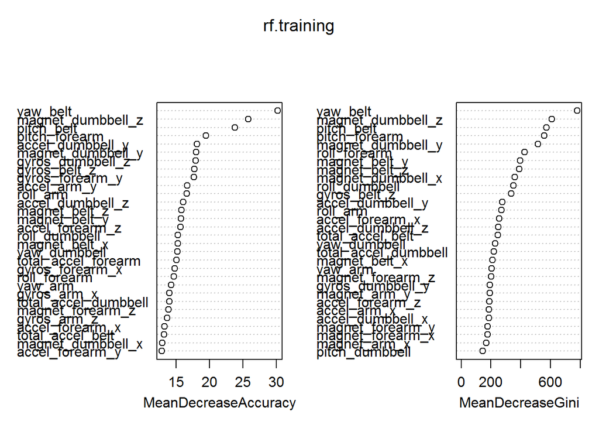

```r
varImpPlot(rf.training,)
```

we can see which variables have higher impact on the prediction.

## Out-of Sample Accuracy

Now lets evaluate this tree on the test data.

```r
tree.pred=predict(rf.training,testing,type="class")
predMatrix = with(testing,table(tree.pred,classe))
sum(diag(predMatrix))/sum(as.vector(predMatrix)) # error rate
```

```
## [1] 0.9954121
```

0.99 means we got a very accurate estimate.

## Conclusion

```r
answers <- predict(rf.training, testingOrg)
answers
```

[output not shown]

[output cut: 3218 more lines]

[output not shown]